# Communicate Data Findings: RITA Flight Data in 2008

## Dataset Overview

This dataset reports flights in the United States, including carriers, arrival and departure delays, and reasons for delays in 2008. The data comes originally from RITA

- There are 2389217 flights in the dataset with 21 variables.
- Numeric varibles like ActualElapsedTime are time related variables.
- Measurement of time related variables is minutes

## Distribution of the main variable of interest:

1. ArrDelay: arrival delay, in minutes
2. DepDelay:departure delay, in minute

Arrival delay and Departure delay are long tail in the distribution with outliers. Therefore outliers eliminated with IQR. Both Arrival Delay and Departure Delay are unimodal and skewed right. Arrival Delay plot seems beautifully distributed but slightly skewed. Departure Delay looks narrower than a normal distribution.

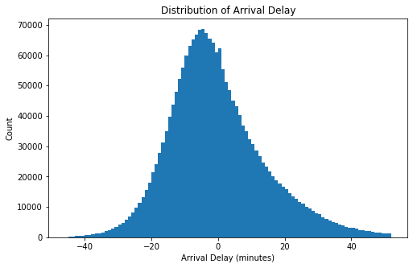

```python
# start again with a standard-scaled(miniutes) plot
# distribution of Arrival Delay

binsize = 1
bins = np.arange(df_filtered['ArrDelay'].min()-binsize, df_filtered['ArrDelay'].max()+binsize*2, binsize)

plt.figure(figsize=[8, 5])
plt.hist(data = df_filtered, x = 'ArrDelay', bins = bins)
plt.xlabel('Arrival Delay (minutes)')
plt.ylabel('Count')
plt.title('Distribution of Arrival Delay')
plt.show()
```

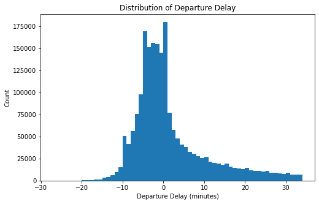

```python
# start again with a standard-scaled(miniutes) plot
# distribution of Departure Delay

binsize = 1
bins = np.arange(df_filtered['DepDelay'].min()-binsize, df_filtered['DepDelay'].max()+binsize*2, binsize)

plt.figure(figsize=[8, 5])
plt.hist(data = df_filtered, x = 'DepDelay', bins = bins)
plt.xlabel('Departure Delay (minutes)')
plt.ylabel('Count')
plt.title('Distribution of Departure Delay')
plt.show()
```

## Bar Plots of categorical variables in the dataset

Day of Week's distribution shows little difference by day. On Wednesday, there are slightly more flights then other days. For carrier names, there are 20 carriers, with Southwest Airlines CO. accounting for the largest number.

The plot of the distribution of Manufacturer shows that about 10 manufacturers make up the majority. it is a long-tail graph and there are outliers need to be modified for analysis. Since manufacturers which have small number of flights can reduce clearity of visualization of data, I decided to leave only major manufacturers. As removing ouliers, I'll include data from major manufacturers with more than 500 flights for anlysis.

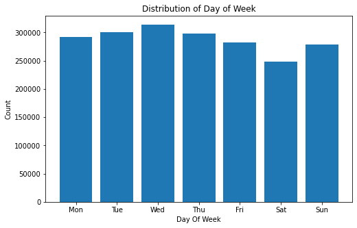

```python
# plotting DayOfWeek

DayOfWeeKLabel = [ 'Mon','Tue','Wed', 'Thu','Fri', 'Sat', 'Sun']

plt.figure(figsize=[8, 5])
plt.bar(x = df_filtered.DayOfWeek.value_counts().keys(), height = df_filtered.DayOfWeek.value_counts() )
plt.xlabel('Day Of Week')
plt.ylabel('Count')
plt.title('Distribution of Day of Week')
plt.xticks( np.arange(1, len(DayOfWeeKLabel)+1), DayOfWeeKLabel)
plt.show()
```

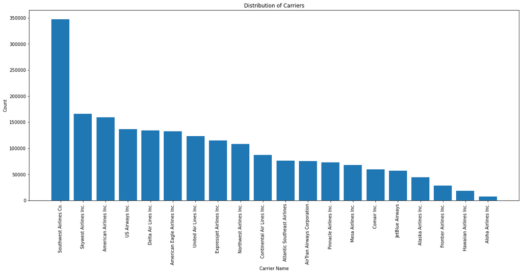

```python
# plotting Carriers

plt.figure(figsize=[20, 8])
plt.bar(x = df_filtered.Carrier_Name.value_counts().keys(), height = df_filtered.Carrier_Name.value_counts() )
plt.xlabel('Carrier Name')
plt.ylabel('Count')
plt.title('Distribution of Carriers')
plt.xticks(rotation=90)
plt.show()
```

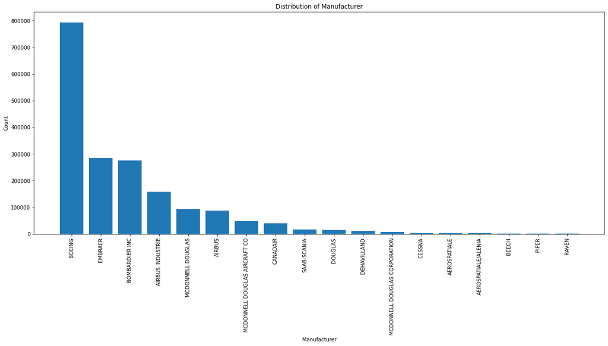

```python
# plotting Manufacturers

plt.figure(figsize=[20, 8])
plt.bar(x = df_filtered.manufacturer.value_counts().keys(), height = df_filtered.manufacturer.value_counts() )
plt.xlabel('Manufacturer')
plt.ylabel('Count')
plt.title('Distribution of Manufacturer')
plt.xticks(rotation=90)
plt.show()
```

## Delays vs. Day of Week

Plotting delays on a day of week shows the relationship between two variables. The difference of delay time between days of the week is not significant. It can be seen that for the Arrival Delay, the distribution was all similar, and Friday has slightly higher mean. In the plot of delay in departure, the distribution varies more than the delay in arrival, and it is also shown that the delay time is longer on Friday.

The second plot shows the mean time of delay for each day of the week. It also shows the longest delay time on Friday. However, the actual practical difference is not that significant because the unit of time delay is 'minutes'.

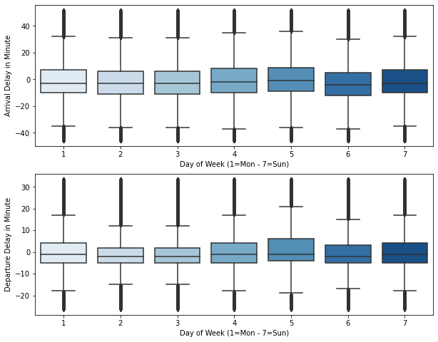

```python
# boxplot Delay Time vs Day of Week

plt.figure(figsize = [10, 8])

# subplot 1: Arrival Delay vs. Day of Week
plt.subplot(2, 1, 1)
sb.boxplot(data = df_filtered, x = 'DayOfWeek', y = 'ArrDelay', palette='Blues')
plt.xlabel('Day of Week (1=Mon - 7=Sun)')
plt.ylabel('Arrival Delay in Minute');

# subplot 2: Departure Delay vs. Day of Week
plt.subplot(2, 1, 2)
sb.boxplot(data = df_filtered, x = 'DayOfWeek', y = 'DepDelay', palette='Blues')
plt.xlabel('Day of Week (1=Mon - 7=Sun)')
plt.ylabel('Departure Delay in Minute');
```

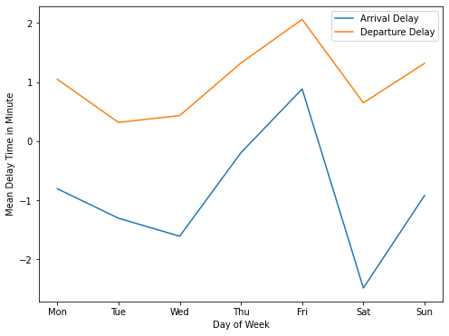

```python
# line plots to observe Mean delay change per day
Delay_mean = df_filtered.groupby('DayOfWeek').agg({'ArrDelay':'mean', 'DepDelay':'mean'})

plt.figure(figsize = [8, 6])
plt.plot( Delay_mean.index, Delay_mean.ArrDelay )
plt.plot( Delay_mean.index, Delay_mean.DepDelay )
plt.xlabel('Day of Week')
plt.ylabel('Mean Delay Time in Minute')
plt.legend(['Arrival Delay', 'Departure Delay'])
plt.xticks( np.arange(1, len(DayOfWeeKLabel)+1), DayOfWeeKLabel)
plt.show()
```

## Delays vs. Manufacturers and Carriers

Interestingly, there are a difference in the mean delay time according to the Manufacturers and Carriers. First of all, the manufacturer with the most delays in arrival was Douglas while the company has a negative departure delay mean. Beech was the manufacturer with the most Departure delays, followed by Boeing. For Carriers, Frontier Airlines has the highest arrival delay mean, and Southwest Airlines Co. has the highest departure delay mean.

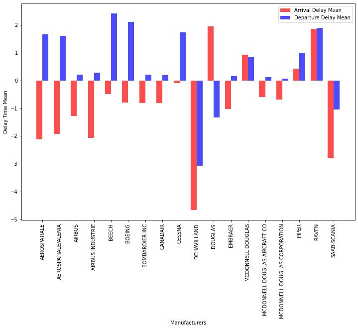

```python
# Bar plots to observe Mean delay change per day
# find mean delay time by manufacturers
Delay_manu = df_filtered.groupby('manufacturer').agg({'ArrDelay':'mean', 'DepDelay':'mean'})

ind = np.arange(len(Delay_manu))  # the x locations for the groups
width = 0.35       # the width of the bars

plt.figure(figsize = [12, 8])
red_bars = plt.bar(ind, Delay_manu['ArrDelay'], width, color='r', alpha=.7, label='Arrival Delay Mean')
blue_bars = plt.bar(ind + width, Delay_manu['DepDelay'], width, color='b', alpha=.7, label='Departure Delay Mean')

# title and labels
plt.ylabel('Delay Time Mean')
plt.xlabel('Manufacturers')
locations = ind + width / 2  # xtick locations

# code ref.
# https://thispointer.com/python-pandas-how-to-get-column-and-row-names-in-dataframe/
labels = Delay_manu.index.values

# code ref.
#https://stackoverflow.com/questions/10998621/rotate-axis-text-in-python-matplotlib
plt.xticks(locations, labels, rotation=90)


# legend
plt.legend() ;
```

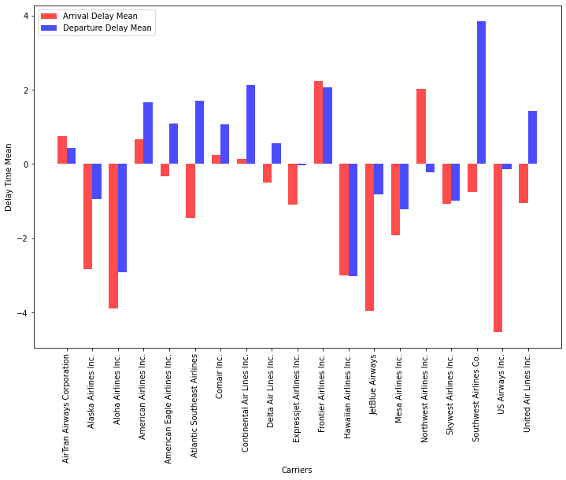

```python
# Bar plots to observe Mean delay change per day
# find mean delay time by manufacturers
Delay_carr = df_filtered.groupby('Carrier_Name').agg({'ArrDelay':'mean', 'DepDelay':'mean'})

ind2 = np.arange(len(Delay_carr))  # the x locations for the groups
width = 0.35       # the width of the bars

plt.figure(figsize = [12, 8])
red_bars = plt.bar(ind2, Delay_carr['ArrDelay'], width, color='r', alpha=.7, label='Arrival Delay Mean')
blue_bars = plt.bar(ind2 + width, Delay_carr['DepDelay'], width, color='b', alpha=.7, label='Departure Delay Mean')

# title and labels
plt.ylabel('Delay Time Mean')
plt.xlabel('Carriers')
locations = ind2 + width / 2  # xtick locations

# code ref.
# https://thispointer.com/python-pandas-how-to-get-column-and-row-names-in-dataframe/
labels = Delay_carr.index.values

# code ref.
#https://stackoverflow.com/questions/10998621/rotate-axis-text-in-python-matplotlib
plt.xticks(locations, labels, rotation=90)


# legend
plt.legend() ;
```

## Arrival Delay by Manufacturers and Carries

Finally, let's look at the arrival delay time by manufacturer and airline through the heat map.

The blanks on the heat map occur because each airline has several selected manufacturer's planes.

First of all, it was the earliest arrival time when it was the airplane of **Airbus Industries** carried by **US Airways Inc**. In other hands, longest arrival delays was shown by **Frontier Airlines.Inc**, which operates planes manufactured by **Airbus Industries**.

It is interesting that even airplanes made by the same manufacturer have different delays depending on carriers.

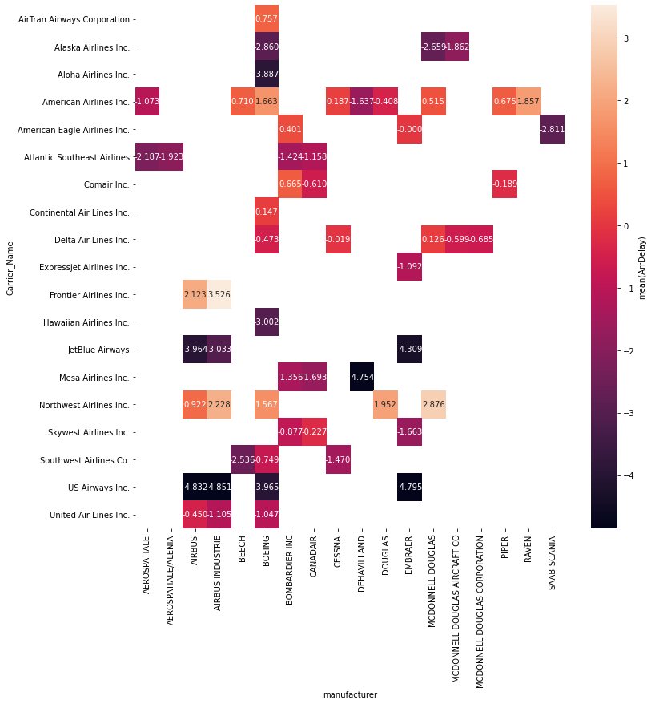

```python
# HeatMap plot: Average Arrival Delay vs. Manufacturers and Carriers
cat_means = df_filtered.groupby(['manufacturer', 'Carrier_Name']).mean()['ArrDelay']
cat_means = cat_means.reset_index(name = 'Arrival_Delay_avg')
cat_means = cat_means.pivot(index = 'Carrier_Name', columns = 'manufacturer',
                            values = 'Arrival_Delay_avg')

plt.figure(figsize=(12,12))

sb.heatmap(cat_means, annot = True, fmt = '.3f',
           cbar_kws = {'label' : 'mean(ArrDelay)'}) ;
```